# 01.TSS_coverage of cfDNA and placenta expression

**1.1 Average expression of the 500 most- (Top500, red) and least-expressed genes (Bottom500, blue) in the placenta of preterm birth pregnancies.**

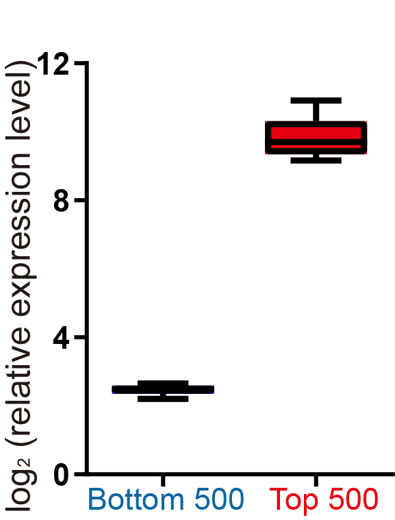

**1.2 Read depth of whole-genome sequencing across pTSS regions (-1 KB to 1 KB around the TSS) from the 500 most- (Top500, red line) and least-expressed (Bottom500, blue line) genes.**

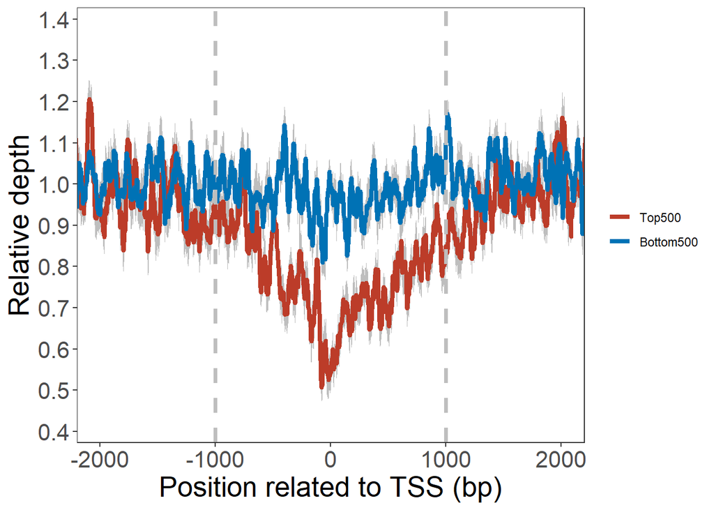

```r
library(ggsci)
library(ggplot2)
library(dplyr)
load("Preterm.RData")
x <- x01
ggplot(x,aes(x = Position,Top))+
geom_ribbon(aes(ymin = R1, ymax=R2), fill="grey")+
geom_ribbon(aes(ymin = R3, ymax=R4), fill="grey")+
geom_line(aes(x = Position,Least,colour="#0072B5FF"),linewidth=1.42)+
geom_line(aes(x = Position,Top,colour="#BC3C29FF"),linewidth=1.42)+
geom_vline(xintercept = c(-1000,1000), linetype="dashed",color="grey", linewidth =1.3)+

theme_bw()+
theme(panel.grid=element_blank(),axis.title = element_text(size = 20),axis.text=element_text(size=16),legend.title=element_blank())+
labs(x="Position related to TSS (bp)",y="Relative depth")+
scale_color_nejm(labels=c("Top500","Bottom500"))+
coord_cartesian(xlim=c(-2000,2000),ylim=c(0.42,1.38))+
scale_y_continuous(breaks = seq(0.4, 1.5, by=0.1))
```

The read depth of the Top500 genes was lower than that of the Bottom500 genes (P-value = 5.3e-197, Wilcoxon rank-sum test).

**1.3 Average expression levels of the housekeeping (red) and unexpressed (blue) genes in the placenta.**

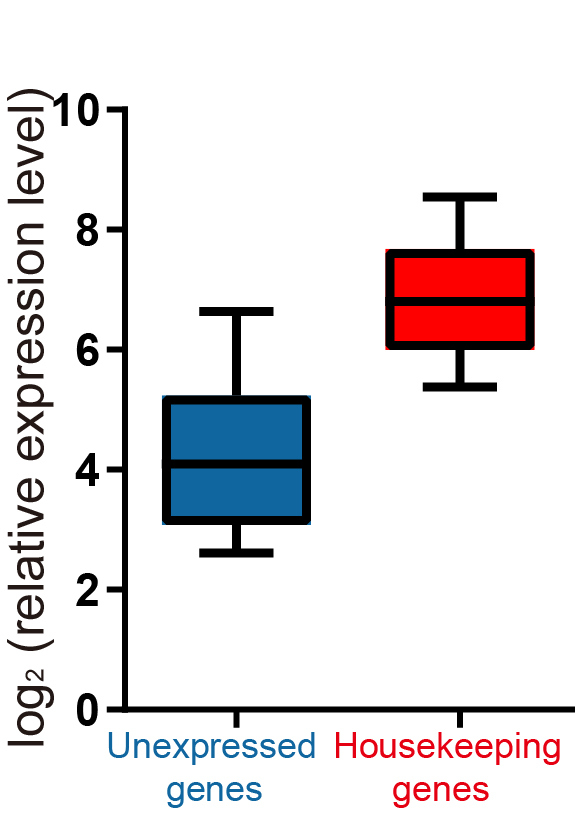

**1.4 Read depth of whole-genome sequencing at the pTSS region (−1KB to +1KB around TSS) of the housekeeping genes (red line) and unexpressed genes.**

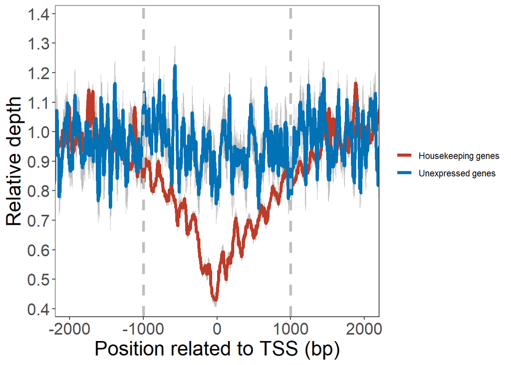

```r
x <- x02
ggplot(x,aes(x = Position,House))+
geom_ribbon(aes(ymin = R1, ymax=R2),fill="grey")+
geom_ribbon(aes(ymin = R3, ymax=R4),fill="grey")+
geom_line(aes(x = Position,UnEx,colour="#0072B5FF"),linewidth=1.42)+
geom_line(aes(x = Position,House,colour="#BC3C29FF"),linewidth=1.42)+
geom_vline(xintercept = c(-1000,1000), linetype="dashed",color="grey", linewidth =1.3)+

theme_bw()+
theme(panel.grid=element_blank(),axis.title = element_text(size = 20),axis.text=element_text(size=16),legend.title=element_blank())+
labs(x="Position related to TSS (bp)",y="Relative depth")+
scale_color_nejm(labels=c("Housekeeping genes","Unexpressed genes"))+
coord_cartesian(xlim=c(-2000,2000),ylim=c(0.42,1.38))+
scale_y_continuous(breaks = seq(0.4, 1.5, by=0.1))
```

The read depth of the housekeeping genes (red line) was lower than that of unexpressed genes (blue line) in the placenta (P-value = 8.529e-142, Wilcoxon rank-sum test)

**1.5 Read depth of placenta-enriched genes in preterm and full-term pregnancies (-5KB to 5KB around TSS).**

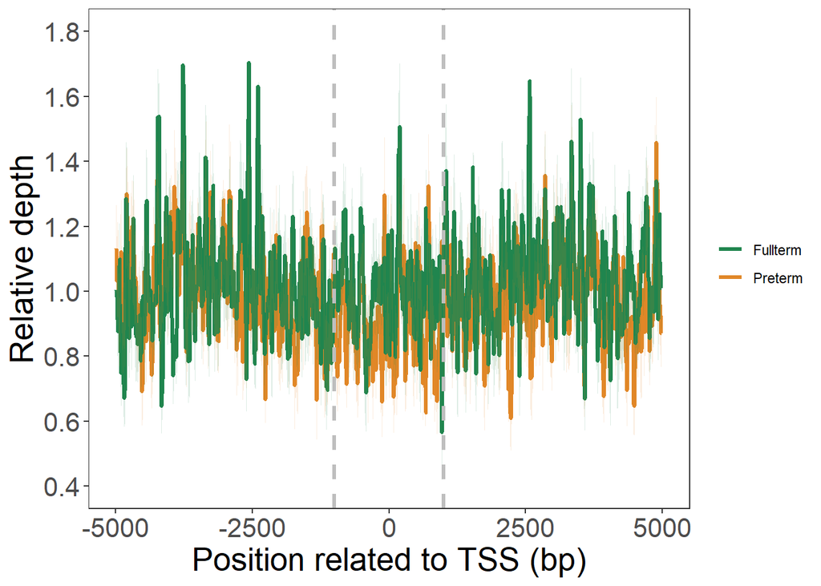

```r
x <- x03
ggplot(x,aes(x = Position,Term))+
geom_line(aes(x = Position,PT,colour="#E18727FF"),linewidth=1.2)+
geom_line(aes(x = Position,Term,colour="#20854EFF"),linewidth=1.2)+
geom_ribbon(aes(ymin = R1, ymax=R2), alpha = 0.15,fill="#E18727FF")+
geom_ribbon(aes(ymin = R3, ymax=R4), alpha = 0.15,fill="#20854EFF")+
geom_vline(xintercept = c(-1000,1000), color="grey", linewidth =1.2, linetype = "dashed")+

theme_bw()+
theme(panel.grid=element_blank(),legend.title = element_blank(),axis.title = element_text(size = 20),axis.text=element_text(size=16))+
scale_colour_manual(values = c("#20854EFF","#E18727FF"),labels=c("Fullterm","Preterm"))+
labs(x="Position related to TSS (bp)",y="Relative depth")+
scale_y_continuous(limits = c(0.4,1.8),breaks=c(0.4,0.6,0.8,1,1.2,1.4,1.6,1.8))+
scale_x_continuous(limits = c(-5000,5000))
```

**1.6 Read depth of placenta-enriched genes in preterm and full-term pregnancies (-1KB to 1KB around TSS)**

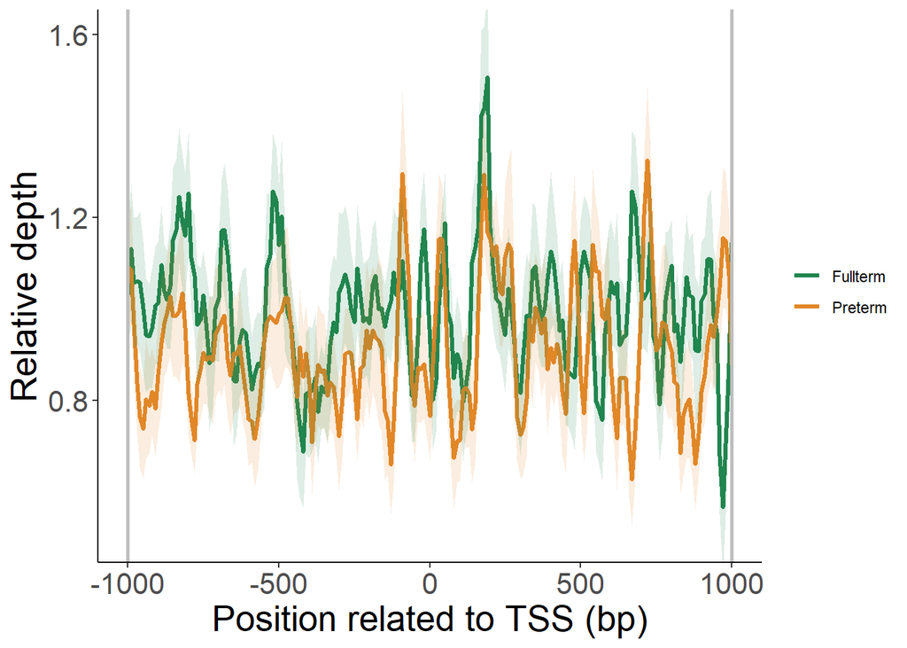

```r
x <- x04
ggplot(x,aes(x = Position,PT))+
geom_line(aes(x = Position,Term,colour="#20854EFF"),linewidth=1.2)+
geom_line(aes(x = Position,PT,colour="#E18727FF"),linewidth=1.2)+
geom_ribbon(aes(ymin = R1, ymax=R2), alpha = 0.15,fill="#E18727FF")+
geom_ribbon(aes(ymin = R3, ymax=R4), alpha = 0.15,fill="#20854EFF")+
geom_vline(xintercept = c(-1000,1000), color="grey", linewidth =1)+
scale_x_continuous(limits = c(-1000,1000))+

theme_classic()+
theme(legend.title = element_blank(),axis.title = element_text(size = 20),axis.text=element_text(size=16))+
labs(x="Position related to TSS (bp)",y="Relative depth")+
scale_colour_manual(values = c("#20854EFF","#E18727FF"),labels=c("Fullterm","Preterm"))+
coord_cartesian(ylim=c(0.5,1.6))
```

The read depth of placenta-enriched genes was shown to be more depleted in the preterm (yellow line) pregnancies than full-term (green line) pregnancies (P-value = 7.386e-11, Wilcoxon rank-sum test)